# Final Exam

STA 235H

Dec. 7th

# Task 1: Oldies but Goodies

**1.1) Thinking about the following regression, where Vote captures whether someone voted or not, Educ captures years of education, Income refers to household income (in thousands of dollars), and PrevPart takes the value of 1 if someone voted in the previous election and 0 if not.**

$$Vote = 0.21 + 0.01 \times Educ +
0.0005\times Educ^2 + 0.001\times Income + 0.18\times
PrevPart$$

**Interpret the association between Vote and Education for someone who just finished high school (12 years) vs someone with one year of college (13 years).** *(4 points)*

*Answer:*

On average, the probability of voting for a person with one year of college is 2.2 percentage points higher compared to someone that just finished high school, holding other variables constant.

OR

On average, increasing years of education from 12 to 13 years is associated with a 0.022 increase in the probability of voting, holding other variables constant.

4 points: Includes (i) On average, (ii) correct estimate (0.022 or 2.2), (iii) correct units (percentage points or unitless - has to correspond to their estimate), (iv) correct comparison (e.g. increase 12 to 13 years or college freshman vs HS grad), and (v) holding other variables constant.

2 points: One of the previous items is not correct.

0 points: Any other case.

# Task 2: Let’s get conceptual

**2.1) You are doing some consulting for a client and are running some prediction models. Your client has some stats background, but doesn’t really know about the models you are running. In your own words, conceptually, briefly explain how Random Forest works.** *(5 points)*

Random forest is an ensamble method that combines several decision trees in parallel using bootstrapped samples of the data. It also de-correlates trees by randomly selecting a subset of the predictors for each split, aggregating the final prediction by either averaging predictions for all trees, or the majority vote.

5 points: Includes (i) Combination of decision trees, (ii) in parallel, (iii) de-correlates trees (iv) by randomly selecting a subset of predictors.

3 points: One of the previous points is not included/incorrect.

1 points: Two of the previous points are not included/incorrect.

0 points: Any other case.

**2.2) This is the output for the example we saw in class for tutoring and exam scores. Here. we have the entrance exam score centered at 70 (`entryscore_c`), whether a student received a tutor (1) or not (0) (`treat`), and the outcome is the exit exam score in a scale from 0 to 100 (`exitscore`). Remember that in this case, students with a score under 70 received a tutor for their freshman year.**

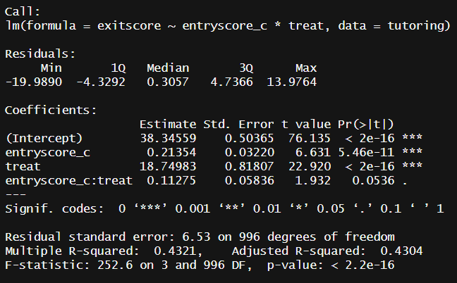

*Interpret the coefficient for `entryscore_c:treat`* *(5 points)*

*Answer:*

On average, one additional point in the entry exam score for students that receive a tutor is associated with an additional 0.11 point increase in their exit exam score compared to the same change for students not assigned to a tutor.

5 points: Includes (i) on average, (ii) difference in association for entry vs exit exam, (iii) comparison between students with a tutor vs not a tutor.

3 points: One of the previous points is not included/incorrect.

1 points: Two of the previous points are not included/incorrect.

0 points: Any other case.

# Task 3.1: Health and Labor

In this task, we will be analyzing data from the Oregon Health Experiment, which we briefly discussed in class and was also included in some of your readings for Mastering Metrics.

In this natural experiment, authorities in Oregon decided to randomize Medicaid access within participants of a lottery, to make a fair assignment of healthcare for people in need.

The experiment worked as follows:

1. People that met certain criteria (e.g. income below the federal poverty level) were eligible to participate and sign up in the lottery.
2. When signing up to the lottery, they had to complete some baseline information about their demographic and socioeconomic characteristics.
3. 12 months later, all participants from the lottery (those who were selected and not selected to get health insurance) completed a follow-up survey with additional information.

You can load the data using the following code and check the codebook here:

```r
oregon = read.csv("https://raw.githubusercontent.com/maibennett/website_github/master/exampleSite/content/results/data/OHIE_ed.csv")
```

**3.1) Create a balance table showing that the treated and control group are comparable. Show your code (everything you need for creating the table after loading the data) AND your table here.** *(5 points)*

*Answer:*

```r
oregon_bal = oregon %>% select(treatment, ends_with("bl"))

oregon_bal = oregon_bal %>% mutate(race_hispanic = ifelse(race_bl == "Hispanic", 1, 0),
                               race_white = ifelse(race_bl == "White", 1, 0),
                               race_black = ifelse(race_bl == "African-American", 1, 0)) %>%
  select(-race_bl)

datasummary_balance(~ treatment, data = oregon_bal, fmt = 2, dinm_statistic = "p.value")
```

|  | 0 Mean | 0 Std. Dev. | 1 Mean | 1 Std. Dev. | Diff. in Means | p |
| --- | --- | --- | --- | --- | --- | --- |
| birthyear_bl | 1965.30 | 12.12 | 1965.55 | 12.03 | 0.25 | 0.25 |
| female_bl | 0.62 | 0.49 | 0.60 | 0.49 | -0.02 | 0.06 |
| health_gen_bl | 2.78 | 1.06 | 2.84 | 1.04 | 0.07 | <0.01 |
| employ_bl | 0.50 | 0.50 | 0.50 | 0.50 | 0.00 | 0.64 |
| hhinc_cat_bl | 6812.85 | 5689.93 | 7298.84 | 5900.00 | 485.99 | <0.01 |
| edu_bl | 12.29 | 2.27 | 12.25 | 2.27 | -0.04 | 0.39 |
| hhsize_bl | 2.95 | 2.45 | 770.98 | 59559.35 | 768.03 | 0.32 |
| race_hispanic | 0.06 | 0.23 | 0.06 | 0.24 | 0.01 | 0.22 |
| race_white | 0.85 | 0.35 | 0.84 | 0.36 | -0.01 | 0.16 |
| race_black | 0.02 | 0.15 | 0.02 | 0.15 | 0.00 | 0.92 |

5 points: (i) Includes only baseline variables (no follow-up or ids), (ii) creates binary variables for race, and (iii) compares the two groups correctly (e.g. magnitudes are correct).

3 points: One of the previous points is not included/incorrect.

1 points: Two of the previous points are not included/incorrect.

0 points: Any other case.

*Discount 1 point if number of decimals is not correct*

**3.2) Are your groups balanced?** *(2 points)*

1. Yes, all confounders are balanced.
2. No, some confounders are not balanced.

*Answer:*

B

**3.3a) Run a simple regression to assess the effect of healthcare access on being employed 12 months later. Fill in the blank with the corresponding line of code:** *(3 points)*

*Answer:*

```r
lm_ohie = lm_robust(employ_fu ~ treatment, data = oregon)
```

**3.3b) What is the estimated effect of the previous model?** *(3 points)*

*Answer:*

```r
summary(lm_ohie)
```

```
##
## Call:
## lm_robust(formula = employ_fu ~ treatment, data = oregon)
##
## Standard error type:  HC2
##
## Coefficients:
##             Estimate Std. Error t value Pr(>|t|) CI Lower CI Upper    DF
## (Intercept)  0.46198   0.006356  72.686 0.000000 0.449518  0.47443 12167
## treatment    0.02447   0.009052   2.704 0.006864 0.006732  0.04222 12167
##
## Multiple R-squared:  0.0006005 , Adjusted R-squared:  0.0005184
## F-statistic: 7.311 on 1 and 12167 DF,  p-value: 0.006864
```

(Answers in percentage points were also accepted).

**3.4) Interpret the previous estimate that you found in 3.3b** *(4 points)*

*Answer:*

On average, being selected in the lottery for access to Medicaid increases the probability of employment 12 months later by 2.4 percentage points compared to not being selected in the lottery.

OR

On average, being selected in the lottery for access to Medicaid increases the probability of employment 12 months later by 0.02 compared to not being selected in the lottery.

4 points: (i) On average, (ii) increase in probability (either percentage points or unitless – estimate has to be appropriate), (iii) makes the contrast between being selected vs not being selected, (iv) correctly identifies the outcome (employment 12 months later).

2 points: One of the previous points is not included/incorrect.

1 points: Two of the previous points are not included/incorrect.

0 points: Any other case.

# Task 3.2: Health and Labor (Continuation)

You can find the data here (you can use the same codebook as before):

```r
oregon_obs = read.csv("https://raw.githubusercontent.com/maibennett/website_github/master/exampleSite/content/results/data/OHIE_ed_obs.csv")
```

**3.6) In this new setup and with all the information provided in the data, can we obtain a causal effect by comparing the average employment rates between individuals that receive Medicaid and those that do not? Why or why not? Provide a specific example.** *(5 points)*

*Answer:*

Comparing both groups will most likely not yield a causal effect due to unobserved confounding. An example could be support networks and/or connections; lack of opportunities could directly affect someone’s income if they are not able to have access to higher paying jobs, and, at the same time, it can directly affect the probability of finding a job at all.

5 points: Identifies that unobserved confounding is a problem and gives a clear example (making both links) of a variable that would affect income and employment.

3 points: Identifies confounding as a problem, but doesn’t provide a clear example of an unobserved confounder (outside the data)/ doesn’t make the link for income and employment/ identifies an observed confounder.

1 points: Identifies confounding as a problem, but overall the example is not correct.

0 points: Any other case.

**3.7) Using the previous information and the new assignment mechanism for Medicaid, how would you estimate a causal effect now? Show the appropriate code here.** *(5 points)*

*Answer:*

Two answers will be accepted here:

```r
# Because treated below the threshold, the sign needs to be inverted

summary(rdrobust(y = oregon_obs$employ_fu, x = oregon_obs$hhinc_cat_bl, c = 30000))
```

```
## Sharp RD estimates using local polynomial regression.
##
## Number of Obs.                 5673
## BW type                       mserd
## Kernel                   Triangular
## VCE method                       NN
##
## Number of Obs.                 3885         1788
## Eff. Number of Obs.            1271          963
## Order est. (p)                    1            1
## Order bias  (q)                   2            2
## BW est. (h)                6788.342     6788.342
## BW bias (b)               10219.711    10219.711
## rho (h/b)                     0.664        0.664
## Unique Obs.                    3885         1788
##
## =============================================================================
##         Method     Coef. Std. Err.         z     P>|z|      [ 95% C.I. ]
## =============================================================================
##   Conventional    -0.109     0.045    -2.450     0.014    [-0.196 , -0.022]
##         Robust         -         -    -2.052     0.040    [-0.214 , -0.005]
## =============================================================================
```

or:

```r
oregon_obs = oregon_obs %>% mutate(r = 30000 - hhinc_cat_bl)

summary(lm_robust(employ_fu ~ medicaid*r, data = oregon_obs))
```

```
##
## Call:
## lm_robust(formula = employ_fu ~ medicaid * r, data = oregon_obs)
##
## Standard error type:  HC2
##
## Coefficients:
##                 Estimate  Std. Error t value
## (Intercept) 0.3944672195 0.018678538 21.1187
## medicaid    0.0900083570 0.023801769  3.7816
## r           0.0000015955 0.000001957  0.8153
## medicaid:r  0.0000005218 0.000002249  0.2320
##                                                                                                         Pr(>|t|)
## (Intercept) 0.00000000000000000000000000000000000000000000000000000000000000000000000000000000000000000000002321
## medicaid    0.00015743758137485994652235432589293395722052082419395446777343750000000000000000000000000000000000
## r           0.41493841941637576997692349323187954723834991455078125000000000000000000000000000000000000000000000
## medicaid:r  0.81652174346919093039787185261957347393035888671875000000000000000000000000000000000000000000000000
##                 CI Lower    CI Upper   DF
## (Intercept)  0.357850140 0.431084299 5669
## medicaid     0.043347786 0.136668928 5669
## r           -0.000002241 0.000005432 5669
## medicaid:r  -0.000003887 0.000004930 5669
##
## Multiple R-squared:  0.01442 ,   Adjusted R-squared:  0.0139
## F-statistic: 28.23 on 3 and 5669 DF,  p-value: < 0.00000000000000022
```

5 points: Runs a regression discontinuity design and code is correct.

4 points: Tries to run a regression discontinuity design, but code is not entirely correct.

2 points: Runs a regression with all potential confounders available in the data/Uses matching

0 points: Any other case.

**3.8) What is the effect of health care access on employment after 12 months in this new setup?**

*Answer:*

0.109 if using `rdrobust` or 0.09 if using a linear model. (Answers in percentage points were also accepted).

# Task 4: Click, click, click

In this task, we want to predict the number of clicks an ad would get on a platform based on different characteristics.

```r
ad = read.csv("https://raw.githubusercontent.com/maibennett/website_github/master/exampleSite/content/results/data/ad_data.csv")
```

**4.1) Split your data into train.data and test.data using a 75%-25% split. In this case, use a stratification approach and stratify by the outcome variable for splitting. What is the average outcome in your training dataset?** *(3 points)*

*Answer:*

```r
set.seed(123)

split = initial_split(ad, prop = 0.75, strata = "clicks")

train.data = training(split)
test.data = testing(split)

train.data %>% summarize(mean(clicks)) %>% round(., 2)
```

| mean(clicks) |
| --- |
| 33809.65 |

**4.2) Run a linear model (without cross-validation) with all the predictors in your dataset. How does your model perform?** *(3 points)*

*Answer:*

```r
lm_all = lm(clicks ~ . - ad_id, data = train.data)

rmse(lm_all, test.data)
```

```
## [1] 2052.391
```

**4.3a) Run a forward stepwise selection model now, Show your code here:** *(4 points)*

*Answer:*

```r
num_pred = length(lm_all$coefficients) - 1

set.seed(123)

lm.fwd = train(clicks ~ . - ad_id,
              data = train.data,
              trControl = trainControl(method = "cv", number = 10),
              method = "leapForward",
              tuneGrid = data.frame(nvmax = 1:num_pred))
```

4 points: (i) Correct model (excludes ad_id) and data, (ii) correct method and cross-validation, (iii) correct tuneGrid (1:13, or calculates the number of coefficients correctly).

1 point: One of the previous items is not correct.

0 points: Any other case.

**4.3b) What is the optimal number of predictors used in the previous forward stepwise selection model?** *(2 points)*

*Answer:*

```r
lm.fwd$bestTune$nvmax
```

```
## [1] 11
```

**4.3c) Hows does your previous model perform?** *(2 points)*

*Answer:*

```r
rmse(lm.fwd, test.data) %>% round(.,2)
```

```
## [1] 2051.15
```

**4.4a) Let’s shrink some coefficients! Use a lasso approach, tuning your lambda parameter between 16 and 18, using a vector of length 100. Include your code here:** *(4 points)*

*Answer:*

```r
set.seed(123)

lasso = train(clicks ~ . - ad_id,
              data = train.data,
              trControl = trainControl(method = "cv", number = 10),
              method = "glmnet",
              preProcess = "scale",
              tuneGrid = expand.grid(alpha = 1,
                                     lambda = seq(16,18, length=100)))
```

4 points: (i) Correct model (excludes ad_id) and data, (ii) correct method and cross-validation, (iii) correct tuneGrid (alhpa = 1 and correct lambda).

1 point: One of the previous items is not correct (don’t discount again if not excluding ad_id).

0 points: Any other case.

**4.4b) How does your previous model perform?** *(2 points)*

*Answer:*

```r
rmse(lasso, test.data) %>% round(.,2)
```

```
## [1] 2044.77
```

**4.5) Finally, let’s fit a random forest with 50 trees. Show your code here:** *Note: Use a minimum node size of 2 and only tune for the optimal number of predictors selected. (5 points)*

*Answer:*

```r
tuneGrid = expand.grid(
  mtry = 1:num_pred, # Number of random covariates that will test
  splitrule = "variance",
  min.node.size = 2
)


set.seed(123)

rf = train(clicks ~ . - ad_id,
           data = train.data,
           trControl = trainControl(method = "cv", number = 10),
           method = "ranger",
           num.trees = 50,
           importance = "permutation",
           tuneGrid = tuneGrid)
```

5 points: (i) Correct model (excludes ad_id) and data, (ii) correct method and cross-validation, (iii) correct tuneGrid (mtry = 1:13 or 1:nvars or similar, and correct min.node.size), (iv) correct number of trees.

3 points: One of the previous items is not correct (don’t discount again if not excluding ad_id).

1 point: Two of the previous items are not correct (don’t discount again if not excluding ad_id)

0 points: Any other case.

**4.6) Which one is the most important variable for prediction in the previous random forest?** *(2 points)*

1. Time of day
2. Top-right position
3. Age
4. Quality rating

*Answer:*

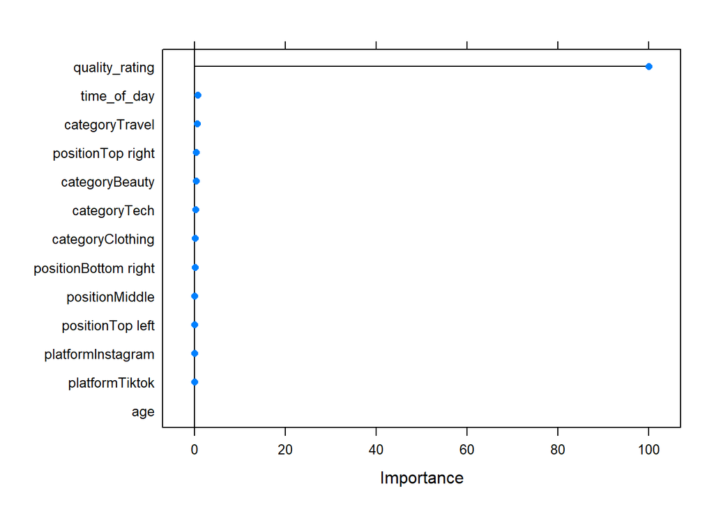

```r
plot(varImp(rf, scale = TRUE))
```

D

**4.7) Which of the following models would you choose?** *(2 points)*

1. Full linear model
2. Forward stepwise selection
3. Lasso
4. Random Forest

*Answer:*

Let’s look again at the RMSEs:

```r
# linear model
rmse(lm_all, test.data) %>% round(.,2)
```

```
## [1] 2052.39
```

```r
#stepwise
rmse(lm.fwd, test.data) %>% round(.,2)
```

```
## [1] 2051.15
```

```r
#lasso
rmse(lasso, test.data) %>% round(.,2)
```

```
## [1] 2044.77
```

```r
#RF
rmse(rf, test.data) %>% round(.,2)
```

```
## [1] 2194.66
```

C

**4.8) Briefly compare the method for your best model vs the method for your worst model. Highlight at least one difference between the two models.**

*Answer:*

Our best model was lasso, while the one that performed the worst was random forest (RF). One difference between these two methods is that lasso is a parametric model while RF is nonparametric. RF is also an ensemble method, while lasso, in this case, is a learner by itself. Both try to reduce variance (compared to linear models and bagged trees/single decision tree, respectively), but one uses a regression approach while the other uses decision trees.

5 points: Correctly identifies at least one difference between the two models.

3 points: Correctly describes the models, but doesn’t really highlight a difference/ Correctly highlights a difference between two models, but they are not the right ones.

1 points: Correctly describes one model, but not the other

0 points: Any other case.